# Homework lecture 1

André Waage Rivenæs

29 9 2019

Alle oppgavene er basert på Bergen bysykkel-dataen.

Kjør følgende kodesnutt for å komme igang:

```r
# Get data
base_url <- "http://data.urbansharing.com/bergenbysykkel.no/trips/v1/2018/"
months <- seq(6, 12)
list_urls <- paste0(base_url, sprintf('%0.2d', months), ".csv")

df_raw <- map_df(list_urls, ~ read_csv(.x))

# Clean data
# Remove trips to service stations
# Remove trips that start and end same place
df <- df_raw %>%
  filter(!(end_station_name %in% c("workshop", "UIP"))) %>%
  filter(duration < 3600) %>%
  filter(start_station_name != end_station_name)

# Add variables
# Merk: geosphere er egen pakke, last ned på forhånd med install.packages("geosphere")
df <- df %>%
  mutate(duration_minutes = duration %/% 60,
         month = month(started_at),
         wday = factor(wday(started_at)),
         time_of_day_started = hour(started_at),
         distance_trip = round(geosphere::distCosine(cbind(start_station_longitude, start_station_latitude),
                                            cbind(end_station_longitude, end_station_latitude))))

# smaller dataset containing only trips started at the most popular station
df_mdp <- df %>%
  filter(start_station_name == "Møllendalsplass")
```

Oppgavene skal leveres til andre.rivenaes@pwc.com og thomas.langeland@pwc.com innen 17. oktober. Oppgaven skal løses i RMarkdown og du skal sende løsningen din både i .rmd-versjon og i .html (trykk knit oppe til venstre for å få ut html-rapporten).

# 1 Data transformation

I disse oppgavene anbefaler vi å bruke funksjoner fra pakken *dplyr* for å løse oppgavene. For dere med mer erfaring i R kan dere gjerne løse oppgavene både med *dplyr* og *data.table* for bonuspoeng!

## 1.1 Fart

Legg til variabelen “average_speed_kph” i datasettet. Husk at du allerede har “duration” og “distance_trip”.

## 1.2 Strekning

Finn ut hvilken strekning som er mest populær (altså f.eks. Bergen jernbanestasjon –> Akvariet). Vis topp 10 i en tabell.

## 1.3 Flest besøk

Finn ut hvilken stasjon som har totalt sett flest antall besøk (altså kombiner antall ganger en stasjon har vært ende- og startstasjon). Vis topp 10-listen i en tabell som er sortert etter antall besøk.

## 1.4 Regn

Importer datasettet “rain.csv”, som dere har fått tilgjengeliggjort på Drive. Lag så en ny versjon av df, df_filtered, som kun inneholder observasjoner fra 1. juli 2018. Join “rain” med “df_filtered”, basert på nøkkelen “dato”.

Lag så en ny variabel kalt “rain_category” som settes til “Ingen regn” dersom rain = 0, “Litt regn” dersom regn < 5 og “Mye regn” dersom regn > 5. Lag så en tabell som viser antall og andel (i %) dager av de ulike kategoriene. Hint: her trenger du bla. funksjonene left_join og case_when.

## 1.5 Regnkategori

Ta utgangspunkt i df_filtered. Grupper etter “rain_category” og beregn gjennomsnittlig varighet på sykkelturer. Ser du noen sammenheng mellom nedbørsmengde og varighet på turene?

Reflekter også over hvorfor en slik snittbetraktning *ikke* er tilstrekkelig for å trekke en kausal sammenheng.

# 2 Data vasking (tidyr)

I denne delen skal du bruke funksjoner fra pakken *tidyr* for å løse oppgavene.

## 2.1 Tell og spre

Ta utgangspunkt i datasettet ditt, df, og lag en ny dataframe med struktur som anvist under. Bruk pivot_wider eller pivot_longer.

```
## # A tibble: 38 x 39
##    start_station_n~ Nonneseterplass Møllendalsplass Småstrandgaten Nykirken
##    <chr>                      <int>           <int>          <int>    <int>
##  1 Møllendalsplass             1303               0            309      124
##  2 Nonneseterplass                0            1220            163      113
##  3 Nykirken                     163             126            941        0
##  4 Tårnplass                    205             184            176      775
##  5 Solheimsviken                250             359            455       78
##  6 Bergen jernbane~              36             653            329      372
##  7 Småstrandgaten               173             501              0      574
##  8 Nøstetorget                   40              44            144       55
##  9 Gulating                     220             552             59      350
## 10 Media City                   101             262            270      142
## # ... with 28 more rows, and 34 more variables: `Media City` <int>,
## #   Gulating <int>, Tårnplass <int>, Cornerteateret <int>, Akvariet <int>,
## #   Solheimsviken <int>, Nøstetorget <int>, Høyteknologisenteret <int>,
## #   Lysverket <int>, `Bergen jernbanestasjon` <int>, Neumannsgate <int>,
## #   Studentboligene <int>, Jonsvollkvartalet <int>, `ADO arena` <int>,
## #   Rådhuset <int>, Sandvikstorget <int>, Grieghallen <int>,
## #   `Studentsenteret UIB` <int>, Verftet <int>, `Sandviken Brygge` <int>,
## #   `Høgskulen på Vestlandet` <int>, Johanneskirken <int>, `Allehelgens
## #   plass` <int>, Klosteret <int>, `Den Nationale Scene` <int>, `Haukeland
## #   sykehus` <int>, `Studentboligene ved Grønneviken` <int>, `Den
## #   nationale scene 1` <int>, `Høyskolen på Vestlandet` <int>, `Lars
## #   Hilles` <int>, `Østre Murallmeningen` <int>, Klostertet <int>, `Media
## #   Bergen` <int>, Sandviksbodene <int>
```

## 2.2 Samling

Lag et datasett med strukturen under ved å bruke pivot_longer eller pivot_wider. “id” er en unik id som identifiserer hver tur, dvs. at de to første radene under representerer samme sykkeltur (denne variabelen må du lage først).

Ser du hvordan denne datastrukturen ville gjort det enkelt å gjøre beregningen i oppgave 1-3?

```
## # A tibble: 195,498 x 3
##       id stasjon            value
##    <int> <chr>              <chr>
##  1     1 start_station_name Grieghallen
##  2     1 end_station_name   Bergen jernbanestasjon
##  3     2 start_station_name Studentsenteret UIB
##  4     2 end_station_name   Akvariet
##  5     3 start_station_name Tårnplass
##  6     3 end_station_name   Høyteknologisenteret
##  7     4 start_station_name Høyteknologisenteret
##  8     4 end_station_name   Bergen jernbanestasjon
##  9     5 start_station_name Tårnplass
## 10     5 end_station_name   Lysverket
## # ... with 195,488 more rows
```

# 3 Visualisering

## 3.1 Density

Lag et filtrert datasett, df_top_stations, som kun inneholder turer som enten startet fra eller ble avsluttet i en av de topp 10 mest populære stasjonene.

Lag så et density plot for varighet per sykkeltur i disse 10 stasjonene. Bruk geom_density og facet_wrap.

## 3.2 Ridges

Tilsvarende som over ønsker vi density-plot, men du har fått et tips fra en mer erfaren kollega om at pakken “ggridges” produserer estetisk nydelige plots som er en fryd for øyet.

Følg det gode rådet fra din nye yndlingskollega og bruk ggridges til å lage density plots per stasjon.

## 3.3 Sortering

Kollegaen din ser på plottet og rynker på nesen. Umiddelbart innser du at hun trolig er skuffet over at du ikke har sortert plottet etter varighet. Stasjonen med lengst varighet (målt i median) burde vært nederst i figuren. Flaut!

Rett opp i den grove feilen din og redd det skjøre forholdet til din brilliante kollega. Tips: Bruk funksjonen fct_reorder.

## 3.4 Grusomt barplott

Kollegaen din virker fornøyd med plottet og du tror dagen er reddet, men så enkelt er det ikke.

Dessverre viser hun plottet til en karismatisk leder som ikke forstår seg på statistikk, og han sier at plottet ser fint ut, men han skjønner ingenting av hva det representerer.

Derfor ber han om å heller bare kan få et barplot som viser median varighet per stasjon, hvor stasjonene er på x-aksen og median varighet på y-aksen.

Lag koden for å ende opp med det grusomme plottet vist under:

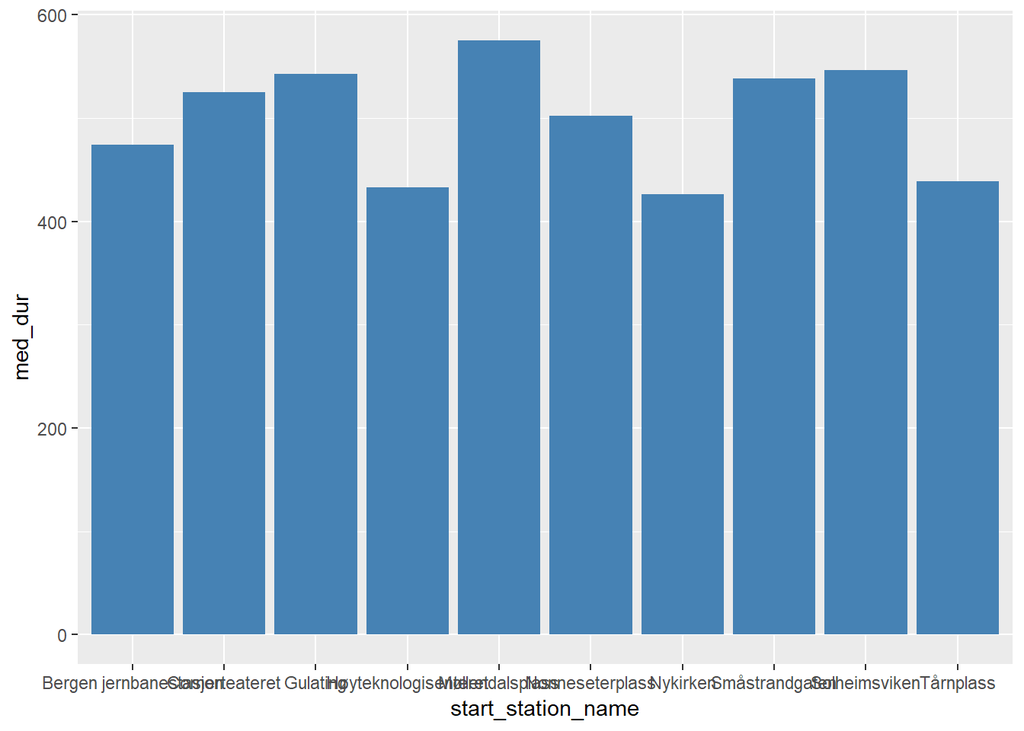

## 3.5 Fiks barplottet

Siden du er en lydig og pliktoppfyllende associate lager du dette kjedelige plottet, men du skjønner kjapt at den svært lite kvantitative lederen din har spesifisert oppgaven på en dårlig måte.

Det ville da vært mye lettere å lese navnene dersom du flippet plottet. I tillegg kunne det vært nyttig med noen labels på barene slik at du kan lese verdiene direkte.

Ta utgangspunkt i plottet over og snu det ved hjelp av “coord_flip”, sorter etter durasjon og legg til labels (geom_label). Legg også til tittel, undertittel og skift tema - generelt, gjør det så fint du klarer!

## 3.6 Opphetet diskusjon

På vei hjem fra jobb overhører du en diskusjon i garderoben:

- Jeg tror de fleste sykler raskere når det regner, fordi folk prøver å komme seg så kjapt som mulig frem for å ikke bli våt.
- Uenig! Jeg tror sykkelturene er tregere når det regner, fordi det er tyngre å sykle i regn og man må være mer forsiktig i svinger og lignende.
- Nehei!
- Joho!
- Neheeeei!
- Johooo!

Du avbryter denne fruktbare diskusjonen og forteller dem at du kan lage dem et plott som (forhåpentligvis) gir dem svar på dette ulidelig spennende spørsmålet.

Illustrer sammenhengen mellom nedbørsmengde og varighet på sykkelturen. Ta gjerne utgangspunktet i kun et utvalg av strekninger. Forklar funnene dine.

## 3.7 En GIF sier mer enn tusen bilder (?)

Når du kommer hjem slenger du deg ned på sofaen, popper en øl og begynner å browse memes på Reddit. Plutselig får du opp en GIF av en korpulent katt som faller ned fra en bokhylle, og du får en genial idé.

- “Hvorfor skal jeg nøye meg med statiske plots, når jeg kan lage GIFs ved hjelp av R- pakken gganimate?” utbryter du mens du kaster deg over PCen igjen med fornyet motivasjon og noe forhøyet promillenivå.

Lag figuren under ved hjelp av pakken gganimate.

[video not shown]

## 3.8 Nettverk

Det nærmer seg leggetid, men plutselig får du en mail fra sjefen din:

- Hei, gidder du å lage et nettverk som viser alle endestasjonene, hvor tykkelsen på forbindelsen mellom nodene avhenger av antall turer? Må selvsagt ha dette innen kl 07:00 i morgen (hehe).

Du er nå blitt en rutinert R-bruker og får ikke panikk til tross for den brutalt korte fristen - du har nemlig lest på Twitter at dette er ganske enkelt med pakken “visNetwork”.

Lag et nettverk som viser alle mulige sykkelruter. Tips: du må først angi “nodes” og “edges”.

# 4 Fri oppgave

Lag en valgfri visualisering av datasettet. Du kan selv velge hva du ønsker å visualisere. Kanskje du kan legge til noen nye variabler først? Her er det bare å være kreativ!

Det blir premie til beste plot.